# Lab 1

Author

Ethan Schultz

```python
import pandas as pd
```

```python
import requests
response = requests.get("https://worldpopulationreview.com/state-rankings/starbucks-stores-by-state#google_vignette")
```

```python
from bs4 import BeautifulSoup
soup = BeautifulSoup(response.content, "html.parser")
```

```python
table = soup.find("table", class_="wpr-table")
table
```

[output not shown]

```python
#1
# initialize an empty list
rows = []

# iterate over all rows in the faculty table
for coffee in table.find_all("tr")[1:]:
    state = coffee.find_all("th")
    cells = coffee.find_all("td")

    # get the state names
    state_tag = state[0].find("a") or state[0]
    states = state_tag.get_text(strip = True)

    # get the different data for years
    year2023_tag = cells[0].find("td") or cells[0]
    year2023 = year2023_tag.get_text(strip = True)

    year2024_tag = cells[2].find("td") or cells[2]
    year2024 = year2024_tag.get_text(strip = True)

    year2021_tag = cells[1].find("td") or cells[1]
    year2021 = year2021_tag.get_text(strip = True)

    # Append this data.
    rows.append({
        "States": states,
        "Starbucks 2021": year2021,
        "Starbucks 2023": year2023,
        "Starbucks 2024": year2024

    })
```

```python
starbucks = pd.DataFrame(rows)
```

|  | States | Starbucks 2021 | Starbucks 2023 | Starbucks 2024 |
| --- | --- | --- | --- | --- |
| 0 | California | 2,959 | 3,080 | 3,117 |
| 1 | Texas | 1,215 | 1,346 | 1,409 |
| 2 | Florida | 786 | 844 | 892 |
| 3 | Washington | 739 | 741 | 736 |
| 4 | New York | 643 | 692 | 715 |
| 5 | Illinois | 621 | 677 | 685 |
| 6 | Arizona | 535 | 548 | 579 |
| 7 | Colorado | 497 | 495 | 506 |
| 8 | Ohio | 446 | 491 | 499 |
| 9 | Virginia | 456 | 489 | 510 |
| 10 | Oregon | 345 | 359 |  |
| 11 | Pennsylvania | 406 | 357 |  |
| 12 | North Carolina | 422 | 338 |  |
| 13 | Georgia | 379 | 326 |  |
| 14 | Michigan | 310 | 283 |  |
| 15 | Massachusetts | 279 | 273 |  |
| 16 | New Jersey | 293 | 261 |  |
| 17 | Maryland | 274 | 257 |  |
| 18 | Nevada | 269 | 253 |  |
| 19 | Indiana | 265 | 221 |  |
| 20 | Missouri | 208 | 188 |  |
| 21 | Minnesota | 212 | 184 |  |
| 22 | Tennessee | 237 | 180 |  |
| 23 | Kentucky | 131 | 166 |  |
| 24 | Wisconsin | 176 | 145 |  |
| 25 | South Carolina | 207 | 131 |  |
| 26 | Connecticut | 125 | 123 |  |
| 27 | Utah | 126 | 101 |  |
| 28 | Hawaii | 105 | 99 |  |
| 29 | Kansas | 120 | 94 |  |
| 30 | District of Columbia |  | 91 |  |
| 31 | Iowa | 142 | 89 |  |
| 32 | Alabama | 99 | 85 |  |
| 33 | Louisiana | 10 | 84 |  |
| 34 | Oklahoma | 94 | 79 |  |
| 35 | New Mexico | 92 | 76 |  |
| 36 | Idaho | 78 | 67 |  |
| 37 | Nebraska | 87 | 58 |  |
| 38 | Arkansas | 66 | 55 |  |
| 39 | Alaska | 49 | 49 |  |
| 40 | Mississippi | 36 | 32 |  |
| 41 | Montana | 45 | 32 |  |
| 42 | Maine | 31 | 30 |  |
| 43 | New Hampshire | 35 | 29 |  |
| 44 | Rhode Island | 26 | 27 |  |
| 45 | Delaware | 39 | 25 |  |
| 46 | South Dakota | 52 | 25 |  |
| 47 | West Virginia | 64 | 25 |  |
| 48 | Wyoming | 26 | 23 |  |
| 49 | North Dakota | 20 | 13 |  |
| 50 | Vermont | 35 | 8 |  |

```python
response = requests.get("https://worldpopulationreview.com/state-rankings/dunkin-donuts-by-state")
soup = BeautifulSoup(response.content, "html.parser")
table1 = soup.find("table", class_="wpr-table")
```

```python
#1b
# initialize an empty list
rows1 = []

# iterate over all rows in the faculty table
for coffee in table1.find_all("tr")[1:]:
    state = coffee.find_all("th")
    cells = coffee.find_all("td")

    # get the state names
    state_tag = state[0].find("a") or state[0]
    states = state_tag.get_text(strip = True)

    # get the different data for years
    year2024_tag = cells[0].find("td") or cells[0]
    year2024 = year2024_tag.get_text(strip = True)

    year2023_tag = cells[1].find("td") or cells[1]
    year2023 = year2023_tag.get_text(strip = True)

    # Append this data.
    rows1.append({
        "States": states,
        "Dunkin-Donuts 2023": year2023,
        "Dunkin-Donuts 2024": year2024,

    })
```

```python
dunkin = pd.DataFrame(rows1)
```

|  | States | Dunkin-Donuts 2023 | Dunkin-Donuts 2024 |
| --- | --- | --- | --- |
| 0 | New York | 1,414 | 1,431 |
| 1 | Massachusetts | 1,068 | 1,042 |
| 2 | Florida | 883 | 909 |
| 3 | New Jersey | 866 | 872 |
| 4 | Illinois | 692 | 711 |
| 5 | Pennsylvania | 629 | 650 |
| 6 | Connecticut | 480 | 476 |
| 7 | Maryland | 303 | 311 |
| 8 | Georgia | 265 | 287 |
| 9 | Ohio | 245 | 261 |
| 10 | Virginia | 230 | 244 |
| 11 | Texas | 196 | 226 |
| 12 | North Carolina | 206 | 224 |
| 13 | New Hampshire | 218 | 216 |
| 14 | Maine | 159 | 164 |
| 15 | Rhode Island | 160 | 159 |
| 16 | California | 134 | 143 |
| 17 | Tennessee | 123 | 137 |
| 18 | Indiana | 104 | 117 |
| 19 | South Carolina | 103 | 116 |
| 20 | Michigan | 105 | 112 |
| 21 | Arizona | 102 | 110 |
| 22 | Wisconsin | 83 | 100 |
| 23 | Alabama | 59 | 69 |
| 24 | Delaware | 66 | 67 |
| 25 | Missouri | 50 | 54 |
| 26 | Kentucky | 41 | 50 |
| 27 | Vermont | 49 | 50 |
| 28 | Colorado | 43 | 48 |
| 29 | Nevada | 38 | 42 |
| 30 | Minnesota | 34 | 38 |
| 31 | Iowa | 34 | 36 |
| 32 | West Virginia | 27 | 31 |
| 33 | Kansas | 28 | 26 |
| 34 | Nebraska | 23 | 24 |
| 35 | Oklahoma | 18 | 23 |
| 36 | District of Columbia |  | 19 |
| 37 | New Mexico | 19 | 19 |
| 38 | Louisiana | 16 | 15 |
| 39 | Arkansas | 9 | 14 |
| 40 | Mississippi | 12 | 14 |
| 41 | Hawaii | 6 | 6 |
| 42 | Utah | 1 | 2 |
| 43 | Wyoming | 1 | 1 |
| 44 | Alaska | 0 | 0 |
| 45 | Idaho | 0 | 0 |
| 46 | Montana | 0 | 0 |
| 47 | North Dakota | 0 | 0 |
| 48 | Oregon | 0 | 0 |
| 49 | South Dakota | 0 | 0 |
| 50 | Washington | 19 | 0 |

```python
merged = starbucks.merge(dunkin, on = ["States"],
how = "outer")
merged.head()
long = merged.melt(id_vars=["States"], value_vars=["Starbucks 2021", "Starbucks 2023", "Starbucks 2024", "Dunkin-Donuts 2023", "Dunkin-Donuts 2024"], var_name="Year_Brand", value_name="stores")
# Split the 'Year_Brand' column into 'Year' and 'Brand'
long[['Brand', 'Year']] = long['Year_Brand'].str.split(' ', expand=True)
# Drop the 'Year_Brand' column if no longer needed
long = long.drop(columns=['Year_Brand'])
long
```

|  | States | stores | Brand | Year |
| --- | --- | --- | --- | --- |
| 0 | Alabama | 99 | Starbucks | 2021 |
| 1 | Alaska | 49 | Starbucks | 2021 |
| 2 | Arizona | 535 | Starbucks | 2021 |
| 3 | Arkansas | 66 | Starbucks | 2021 |
| 4 | California | 2,959 | Starbucks | 2021 |
| ... | ... | ... | ... | ... |
| 250 | Virginia | 244 | Dunkin-Donuts | 2024 |
| 251 | Washington | 0 | Dunkin-Donuts | 2024 |
| 252 | West Virginia | 31 | Dunkin-Donuts | 2024 |
| 253 | Wisconsin | 100 | Dunkin-Donuts | 2024 |
| 254 | Wyoming | 1 | Dunkin-Donuts | 2024 |

255 rows × 4 columns

```python
response = requests.get("https://simple.wikipedia.org/wiki/List_of_U.S._states_by_population")
soup = BeautifulSoup(response.content, "html.parser")

tables = soup.find_all("table", class_ = "wikitable")

#get first table that we want
table = tables[0]

rows = []

for tr in table.find_all("tr")[1:]:
    cells = tr.find_all("td")

    # get states
    state_tag = cells[2].find("a") or cells[2]
    state = state_tag.get_text(strip = True)

    # get population
    pop_tag = cells[3].find("a") or cells[3]
    population = pop_tag.get_text(strip = True)

    # append data
    rows.append({
        "States" : state,
        "population" : population
    })

# convert to a df
population = pd.DataFrame(rows)
population.head()

withpop = long.merge(population, on = "States", how = "left")
```

|  | States | stores | Brand | Year | population |
| --- | --- | --- | --- | --- | --- |
| 0 | Alabama | 99 | Starbucks | 2021 | 5,024,279 |
| 1 | Alaska | 49 | Starbucks | 2021 | 733,391 |
| 2 | Arizona | 535 | Starbucks | 2021 | 7,151,502 |
| 3 | Arkansas | 66 | Starbucks | 2021 | 3,011,524 |
| 4 | California | 2,959 | Starbucks | 2021 | 39,538,223 |
| ... | ... | ... | ... | ... | ... |
| 250 | Virginia | 244 | Dunkin-Donuts | 2024 | 8,631,393 |
| 251 | Washington | 0 | Dunkin-Donuts | 2024 | 7,705,281 |
| 252 | West Virginia | 31 | Dunkin-Donuts | 2024 | 1,793,716 |
| 253 | Wisconsin | 100 | Dunkin-Donuts | 2024 | 5,893,718 |
| 254 | Wyoming | 1 | Dunkin-Donuts | 2024 | 576,851 |

255 rows × 5 columns

```python
# stock prices were grabbed from a quick google search
withpop["Starbucks Stock Price"] = 97.21
withpop["Dunkin Stock Price"] = 106.48
```

```python
withpop.head()
```

|  | States | stores | Brand | Year | population | Starbucks Stock Price | Dunkin Stock Price |
| --- | --- | --- | --- | --- | --- | --- | --- |
| 0 | Alabama | 99.0 | Starbucks | 2021 | 5,024,279 | 97.21 | 106.48 |
| 1 | Alaska | 49.0 | Starbucks | 2021 | 733,391 | 97.21 | 106.48 |
| 2 | Arizona | 535.0 | Starbucks | 2021 | 7,151,502 | 97.21 | 106.48 |
| 3 | Arkansas | 66.0 | Starbucks | 2021 | 3,011,524 | 97.21 | 106.48 |
| 4 | California | 2959.0 | Starbucks | 2021 | 39,538,223 | 97.21 | 106.48 |

```python
#6
state_to_region = {
    "Connecticut": "Northeast", "Maine": "Northeast", "Massachusetts": "Northeast", "New Hampshire": "Northeast",
    "New Jersey": "Northeast", "New York": "Northeast", "Pennsylvania": "Northeast", "Rhode Island": "Northeast",
    "Vermont": "Northeast",
    "Illinois": "Midwest", "Indiana": "Midwest", "Iowa": "Midwest", "Kansas": "Midwest", "Michigan": "Midwest",
    "Minnesota": "Midwest", "Missouri": "Midwest", "Nebraska": "Midwest", "North Dakota": "Midwest",
    "Ohio": "Midwest", "South Dakota": "Midwest", "Wisconsin": "Midwest",
    "Alabama": "South", "Arkansas": "South", "Delaware": "South", "Florida": "South", "Georgia": "South",
    "Kentucky": "South", "Louisiana": "South", "Maryland": "South", "Mississippi": "South",
    "North Carolina": "South", "Oklahoma": "South", "South Carolina": "South", "Tennessee": "South",
    "Texas": "South", "Virginia": "South", "West Virginia": "South",
    "Alaska": "West", "Arizona": "West", "California": "West", "Colorado": "West", "Hawaii": "West",
    "Idaho": "West", "Montana": "West", "Nevada": "West", "New Mexico": "West", "Oregon": "West",
    "Utah": "West", "Washington": "West", "Wyoming": "West"
}
withpop['Region'] = withpop['States'].map(state_to_region)
withpop.head()
# chat gpt was used to quickly make this region mapping
```

|  | States | stores | Brand | Year | population | Starbucks Stock Price | Dunkin Stock Price | Region |
| --- | --- | --- | --- | --- | --- | --- | --- | --- |
| 0 | Alabama | 99.0 | Starbucks | 2021 | 5,024,279 | 97.21 | 106.48 | South |
| 1 | Alaska | 49.0 | Starbucks | 2021 | 733,391 | 97.21 | 106.48 | West |
| 2 | Arizona | 535.0 | Starbucks | 2021 | 7,151,502 | 97.21 | 106.48 | West |
| 3 | Arkansas | 66.0 | Starbucks | 2021 | 3,011,524 | 97.21 | 106.48 | South |
| 4 | California | 2959.0 | Starbucks | 2021 | 39,538,223 | 97.21 | 106.48 | West |

```python
# used chat for this string expression fix the values over 999 and needed to convert stores into numeric
withpop2 = withpop
# gives me an error when this reruns so I commented it out for neatness
#withpop2['stores'] = pd.to_numeric(withpop2['stores'].str.replace(',',''),errors='coerce')
```

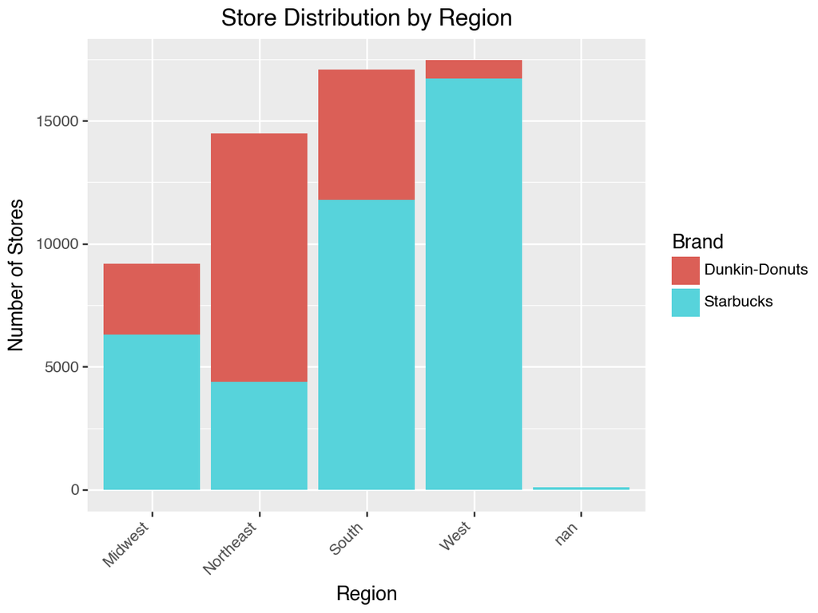

```python
#7
import plotnine
from plotnine import *
(
    ggplot(withpop) +
    aes(x='Region', y='stores', fill='Brand') +
    geom_bar(stat='identity', position='stack') +
    labs(title='Store Distribution by Region', x='Region', y='Number of Stores') +
    theme(axis_text_x=element_text(rotation=45, hjust=1))
)
```

```python
withpop2['population'] = pd.to_numeric(withpop2['population'].str.replace(',',''),errors='coerce')
```

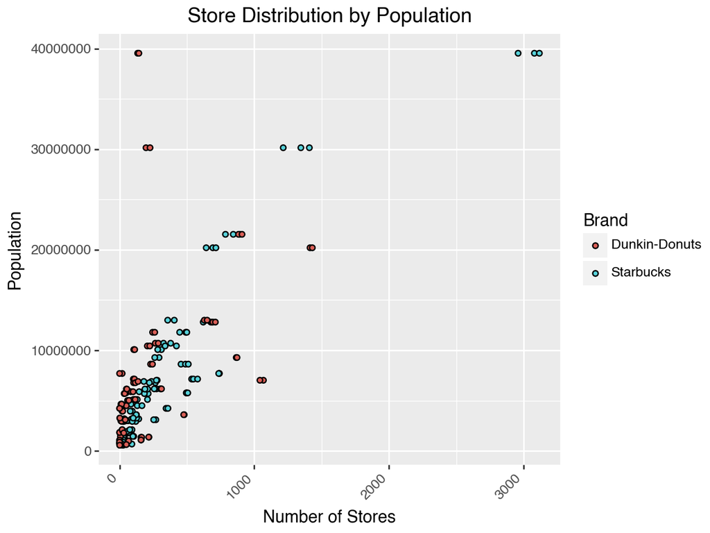

```python
(
    ggplot(withpop2) +
    aes(x='stores', y='population', fill='Brand') +
    geom_point(shape='o') +
    labs(title='Store Distribution by Population', x='Number of Stores', y='Population') +
    theme(axis_text_x=element_text(rotation=45, hjust=1))
)
```

Here we see the number of stores for both Dunkin and Starbucks based on each states population. For both Dunkin and Starbucks their is a positive relationship between the number of people living in that state the the number of locations of each brand which makes sense intuitively.

```python
withpop
```

|  | States | stores | Brand | Year | population | Starbucks Stock Price | Dunkin Stock Price | Region |
| --- | --- | --- | --- | --- | --- | --- | --- | --- |
| 0 | Alabama | 99.0 | Starbucks | 2021 | 5024279 | 97.21 | 106.48 | South |
| 1 | Alaska | 49.0 | Starbucks | 2021 | 733391 | 97.21 | 106.48 | West |
| 2 | Arizona | 535.0 | Starbucks | 2021 | 7151502 | 97.21 | 106.48 | West |
| 3 | Arkansas | 66.0 | Starbucks | 2021 | 3011524 | 97.21 | 106.48 | South |
| 4 | California | 2959.0 | Starbucks | 2021 | 39538223 | 97.21 | 106.48 | West |
| ... | ... | ... | ... | ... | ... | ... | ... | ... |
| 250 | Virginia | 244.0 | Dunkin-Donuts | 2024 | 8631393 | 97.21 | 106.48 | South |
| 251 | Washington | 0.0 | Dunkin-Donuts | 2024 | 7705281 | 97.21 | 106.48 | West |
| 252 | West Virginia | 31.0 | Dunkin-Donuts | 2024 | 1793716 | 97.21 | 106.48 | South |
| 253 | Wisconsin | 100.0 | Dunkin-Donuts | 2024 | 5893718 | 97.21 | 106.48 | Midwest |
| 254 | Wyoming | 1.0 | Dunkin-Donuts | 2024 | 576851 | 97.21 | 106.48 | West |

255 rows × 8 columns

```python
starbucksonly = withpop[(withpop["Brand"] == "Starbucks") & ((withpop["Year"] == "2021") | (withpop["Year"] == "2023"))]
summary = starbucksonly.groupby(["Year", "Region"]).sum("stores").reset_index()
```

|  | States | stores | Brand | Year | population | Starbucks Stock Price | Dunkin Stock Price | Region |
| --- | --- | --- | --- | --- | --- | --- | --- | --- |
| 0 | Alabama | 99.0 | Starbucks | 2021 | 5024279 | 97.21 | 106.48 | South |
| 1 | Alaska | 49.0 | Starbucks | 2021 | 733391 | 97.21 | 106.48 | West |
| 2 | Arizona | 535.0 | Starbucks | 2021 | 7151502 | 97.21 | 106.48 | West |
| 3 | Arkansas | 66.0 | Starbucks | 2021 | 3011524 | 97.21 | 106.48 | South |
| 4 | California | 2959.0 | Starbucks | 2021 | 39538223 | 97.21 | 106.48 | West |
| ... | ... | ... | ... | ... | ... | ... | ... | ... |
| 97 | Virginia | 489.0 | Starbucks | 2023 | 8631393 | 97.21 | 106.48 | South |
| 98 | Washington | 741.0 | Starbucks | 2023 | 7705281 | 97.21 | 106.48 | West |
| 99 | West Virginia | 25.0 | Starbucks | 2023 | 1793716 | 97.21 | 106.48 | South |
| 100 | Wisconsin | 145.0 | Starbucks | 2023 | 5893718 | 97.21 | 106.48 | Midwest |
| 101 | Wyoming | 23.0 | Starbucks | 2023 | 576851 | 97.21 | 106.48 | West |

102 rows × 8 columns

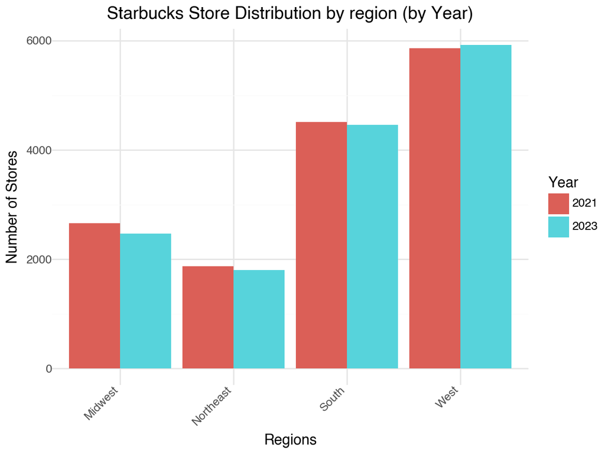

```python
(
    ggplot(summary) +
    aes(x='Region', y='stores', fill = "Year") +
    geom_bar(stat='identity', position='dodge') +
    labs(title='Starbucks Store Distribution by region (by Year)',
         x='Regions', y='Number of Stores') +
    theme_minimal() +
    theme(axis_text_x=element_text(rotation=45, hjust=1))
)
```

From this plot we can see that Strabucks locations across all regions except for the West decreased from 2021 to 2023. 2024 was ommited becasue the majority of states didn’t have data for 2024 yet.

```python
dunkinonly = withpop[(withpop["Brand"]!= "Starbucks") & ((withpop["Year"] == "2023") | (withpop["Year"] == "2024"))]
summary2 = dunkinonly.groupby(["Year", "Region"]).sum("stores").reset_index()
```

|  | States | stores | Brand | Year | population | Starbucks Stock Price | Dunkin Stock Price | Region |
| --- | --- | --- | --- | --- | --- | --- | --- | --- |
| 153 | Alabama | 59.0 | Dunkin-Donuts | 2023 | 5024279 | 97.21 | 106.48 | South |
| 154 | Alaska | 0.0 | Dunkin-Donuts | 2023 | 733391 | 97.21 | 106.48 | West |
| 155 | Arizona | 102.0 | Dunkin-Donuts | 2023 | 7151502 | 97.21 | 106.48 | West |
| 156 | Arkansas | 9.0 | Dunkin-Donuts | 2023 | 3011524 | 97.21 | 106.48 | South |
| 157 | California | 134.0 | Dunkin-Donuts | 2023 | 39538223 | 97.21 | 106.48 | West |
| ... | ... | ... | ... | ... | ... | ... | ... | ... |
| 250 | Virginia | 244.0 | Dunkin-Donuts | 2024 | 8631393 | 97.21 | 106.48 | South |
| 251 | Washington | 0.0 | Dunkin-Donuts | 2024 | 7705281 | 97.21 | 106.48 | West |
| 252 | West Virginia | 31.0 | Dunkin-Donuts | 2024 | 1793716 | 97.21 | 106.48 | South |
| 253 | Wisconsin | 100.0 | Dunkin-Donuts | 2024 | 5893718 | 97.21 | 106.48 | Midwest |
| 254 | Wyoming | 1.0 | Dunkin-Donuts | 2024 | 576851 | 97.21 | 106.48 | West |

102 rows × 8 columns

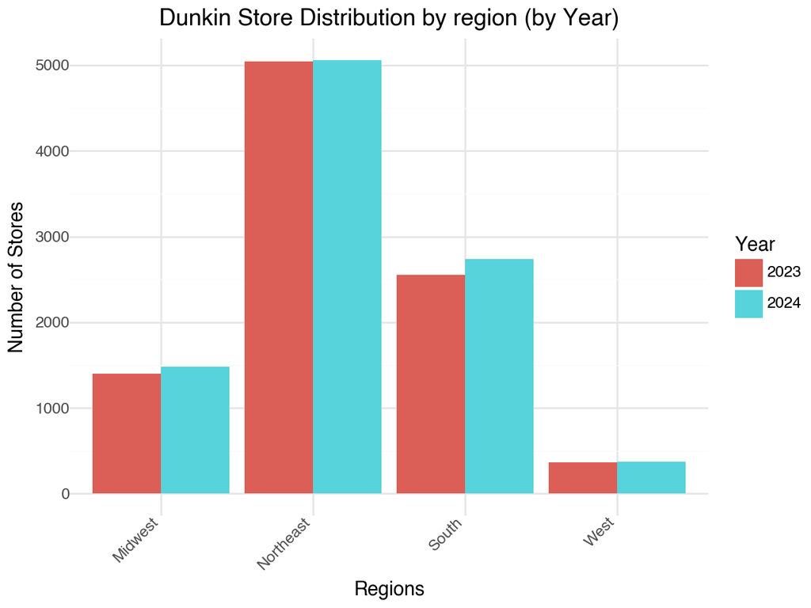

```python
(
    ggplot(summary2) +
    aes(x='Region', y='stores', fill = "Year") +
    geom_bar(stat='identity', position='dodge') +
    labs(title='Dunkin Store Distribution by region (by Year)',
         x='Regions', y='Number of Stores') +
    theme_minimal() +
    theme(axis_text_x=element_text(rotation=45, hjust=1))
)
```

We can see from this plot that from 2023 to 2024 Dunkin saw an increase in store numbers with most noticable increases in locations being in the Midwest and South.

```python
def webscrape(url):
    response = requests.get(url)
    soup = BeautifulSoup(response.content, "html.parser")

    # Extract the company name from the URL
    company_name = re.search(r"state-rankings/(.*?)-stores-by-state", url).group(1).replace("-", " ").title()

    # Gets the first table because we are assuming same format
    table = soup.find_all("table")[0]
    function = []

    # loops through each row getting state name and number of stores
    for row in table.find_all("tr")[1:]:
        state = row.find("th").text.strip()
        stores = row.find("td").text.strip()

        function.append({
            "State": state,
            "Stores": stores,
            "Company": company_name
        })

    # Convert list of dictionaries to a DataFrame
    function = pd.DataFrame(function)
    return function

# Test the function with the Walmart URL
webscrape("https://worldpopulationreview.com/state-rankings/walmart-stores-by-state")
```

|  | State | Stores | Company |
| --- | --- | --- | --- |
| 0 | Texas | 517 | Walmart |
| 1 | Florida | 341 | Walmart |
| 2 | California | 280 | Walmart |
| 3 | North Carolina | 192 | Walmart |
| 4 | Georgia | 189 | Walmart |
| 5 | Illinois | 161 | Walmart |
| 6 | Ohio | 146 | Walmart |
| 7 | Missouri | 137 | Walmart |
| 8 | Tennessee | 137 | Walmart |
| 9 | Pennsylvania | 134 | Walmart |
| 10 | Virginia | 134 | Walmart |
| 11 | Alabama | 131 | Walmart |
| 12 | Oklahoma | 122 | Walmart |
| 13 | Arkansas | 120 | Walmart |
| 14 | Louisiana | 116 | Walmart |
| 15 | Indiana | 113 | Walmart |
| 16 | Arizona | 112 | Walmart |
| 17 | South Carolina | 110 | Walmart |
| 18 | New York | 98 | Walmart |
| 19 | Michigan | 94 | Walmart |
| 20 | Kentucky | 93 | Walmart |
| 21 | Wisconsin | 89 | Walmart |
| 22 | Colorado | 88 | Walmart |
| 23 | Mississippi | 78 | Walmart |
| 24 | Kansas | 74 | Walmart |
| 25 | Minnesota | 68 | Walmart |
| 26 | Washington | 66 | Walmart |
| 27 | New Jersey | 62 | Walmart |
| 28 | Iowa | 60 | Walmart |
| 29 | Utah | 53 | Walmart |
| 30 | Maryland | 48 | Walmart |
| 31 | Massachusetts | 48 | Walmart |
| 32 | New Mexico | 46 | Walmart |
| 33 | Oregon | 45 | Walmart |
| 34 | Nevada | 43 | Walmart |
| 35 | Nebraska | 42 | Walmart |
| 36 | West Virginia | 39 | Walmart |
| 37 | Connecticut | 33 | Walmart |
| 38 | Idaho | 26 | Walmart |
| 39 | New Hampshire | 26 | Walmart |
| 40 | Maine | 22 | Walmart |
| 41 | South Dakota | 15 | Walmart |
| 42 | Montana | 14 | Walmart |
| 43 | North Dakota | 14 | Walmart |
| 44 | Wyoming | 12 | Walmart |
| 45 | Hawaii | 10 | Walmart |
| 46 | Alaska | 9 | Walmart |
| 47 | Rhode Island | 9 | Walmart |
| 48 | Vermont | 6 | Walmart |
| 49 | District of Columbia | 3 | Walmart |

```python
#make sure it still works on earlier starbucks one
webscrape("https://worldpopulationreview.com/state-rankings/starbucks-stores-by-state#google_vignette")
```

|  | State | Stores | Company |
| --- | --- | --- | --- |
| 0 | California | 3,080 | Starbucks |
| 1 | Texas | 1,346 | Starbucks |
| 2 | Florida | 844 | Starbucks |
| 3 | Washington | 741 | Starbucks |
| 4 | New York | 692 | Starbucks |
| 5 | Illinois | 677 | Starbucks |
| 6 | Arizona | 548 | Starbucks |
| 7 | Colorado | 495 | Starbucks |
| 8 | Ohio | 491 | Starbucks |
| 9 | Virginia | 489 | Starbucks |
| 10 | Oregon | 359 | Starbucks |
| 11 | Pennsylvania | 357 | Starbucks |
| 12 | North Carolina | 338 | Starbucks |
| 13 | Georgia | 326 | Starbucks |
| 14 | Michigan | 283 | Starbucks |
| 15 | Massachusetts | 273 | Starbucks |
| 16 | New Jersey | 261 | Starbucks |
| 17 | Maryland | 257 | Starbucks |
| 18 | Nevada | 253 | Starbucks |
| 19 | Indiana | 221 | Starbucks |
| 20 | Missouri | 188 | Starbucks |
| 21 | Minnesota | 184 | Starbucks |
| 22 | Tennessee | 180 | Starbucks |
| 23 | Kentucky | 166 | Starbucks |
| 24 | Wisconsin | 145 | Starbucks |
| 25 | South Carolina | 131 | Starbucks |
| 26 | Connecticut | 123 | Starbucks |
| 27 | Utah | 101 | Starbucks |
| 28 | Hawaii | 99 | Starbucks |
| 29 | Kansas | 94 | Starbucks |
| 30 | District of Columbia | 91 | Starbucks |
| 31 | Iowa | 89 | Starbucks |
| 32 | Alabama | 85 | Starbucks |
| 33 | Louisiana | 84 | Starbucks |
| 34 | Oklahoma | 79 | Starbucks |
| 35 | New Mexico | 76 | Starbucks |
| 36 | Idaho | 67 | Starbucks |
| 37 | Nebraska | 58 | Starbucks |
| 38 | Arkansas | 55 | Starbucks |
| 39 | Alaska | 49 | Starbucks |
| 40 | Mississippi | 32 | Starbucks |
| 41 | Montana | 32 | Starbucks |
| 42 | Maine | 30 | Starbucks |
| 43 | New Hampshire | 29 | Starbucks |
| 44 | Rhode Island | 27 | Starbucks |
| 45 | Delaware | 25 | Starbucks |
| 46 | South Dakota | 25 | Starbucks |
| 47 | West Virginia | 25 | Starbucks |
| 48 | Wyoming | 23 | Starbucks |
| 49 | North Dakota | 13 | Starbucks |
| 50 | Vermont | 8 | Starbucks |

Chat gpt was used for various things throughout this lab, specific things are the mapping of each of the states to regions, various small bugs when plotting each of the four graphs, and helped me figure out the way to write the function in the last part, specifically interating through the rows and getting the compnay name from the URL. Usually this consisted of giving an solid structure to chat gpt and it fine tuining it based on small modification needed to fufill lab requirements.